# Puntos prácticos taller 3-Series de tiempo II

Leydi Agudelo Restrepo

5 de diciembre de 2018

## Punto 3

Simular T = 1000 observaciones ${z_t}$ de un proceso ARFIMA(1; d; 0), con $\phi=0.6$ y $d =0,45$:

1. Haga un gráfico de los datos simulados y comente

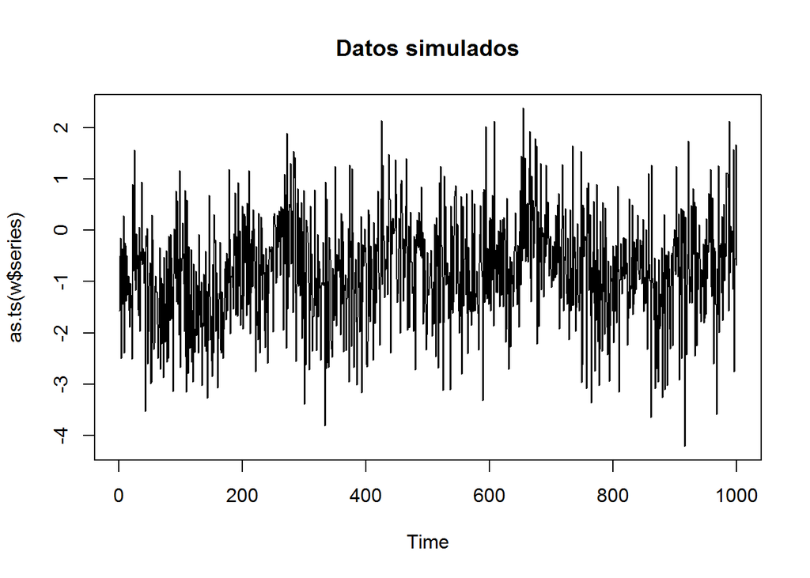

Los datos simulados presentan volatilidad en algunos puntos.

2. Calcule la ACF y PACF muestral y comente.

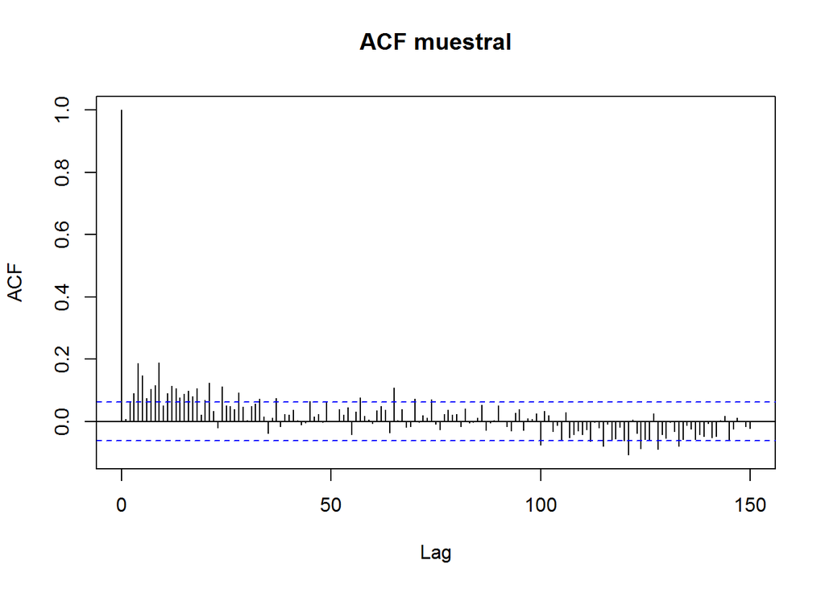

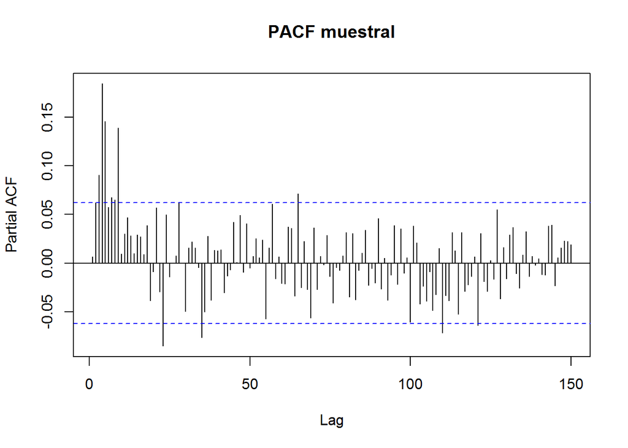

3. Estime los parámetros del modelo, probando las significancia de cada uno de ellos.

A continuación se observan las estimaciones de los parámetros del modelo y además que tanto d como la componente ma1 son significativas.

```
##
## Call:
##   fracdiff(x = w$series, nma = 1, dtol = NULL, drange = c(0, 0.5),      M = 100)
##
## Coefficients:
##    Estimate Std. Error z value Pr(>|z|)
## d   0.44271    0.01172   37.78   <2e-16 ***
## ma  0.56437    0.02899   19.47   <2e-16 ***
## ---
## Signif. codes:  0 '***' 0.001 '**' 0.01 '*' 0.05 '.' 0.1 ' ' 1
## sigma[eps] = 1.024362
## [d.tol = 0.0001221, M = 100, h = 1.523e-05]
## Log likelihood: -1444 ==> AIC = 2894.105 [3 deg.freedom]
```

4. Ajuste un modelo ARMA a $x_t= (1-B)z_t$:

```
##
## Call:
## arima(x = w$series, order = c(1, 0, 1))
##
## Coefficients:
##          ar1      ma1  intercept
##       0.9774  -0.9241    -0.7949
## s.e.  0.0103   0.0170     0.1065
##
## sigma^2 estimated as 1.065:  log likelihood = -1450.59,  aic = 2909.18
```

5. Compare el ajuste de los modelos ARFIMA (ítem c) y ARMA (ítem d).

Basandonos en el criterio de comparación del AIC observamos que con el modelo ARFIMA obtuvimos un AIC=2894.105 y con el modelo ARMA UN AIC=2909.18, por lo tanto el modelo ARFIMA proporcionó un mejor ajuste pues tiene un AIC menor.

## Punto 4

Considere la serie $r_t$ de retornos diarios(cierre) del DJIA(archivo dow.xls). Sea la serie de retornos al cuadrado, $\nu_t= r^2_t$, que representa la serie de volatilidades.

1. Calcule las funciones de autocorrelación y autocorrelación parcial muestral de la serie $\nu$ y comente.

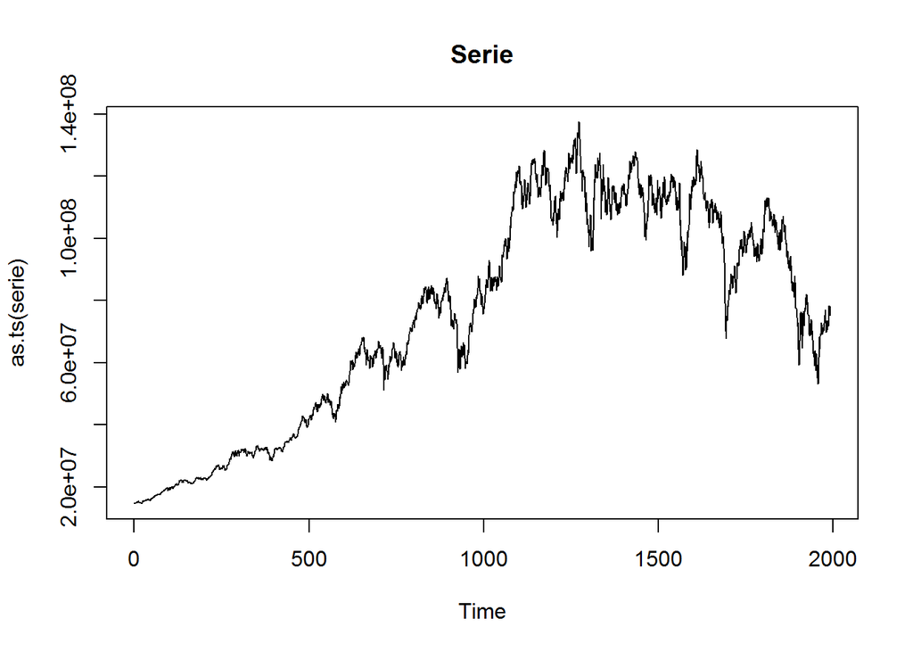

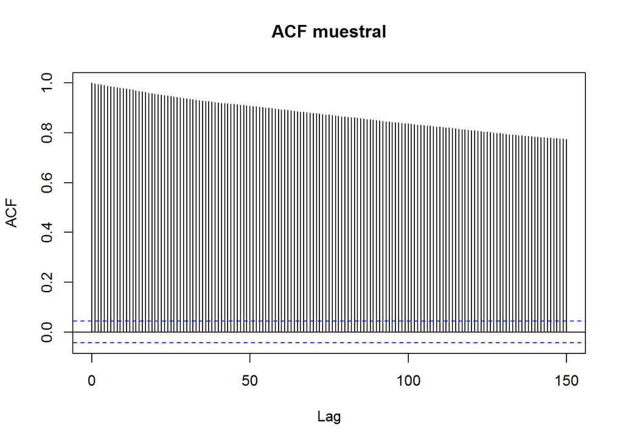

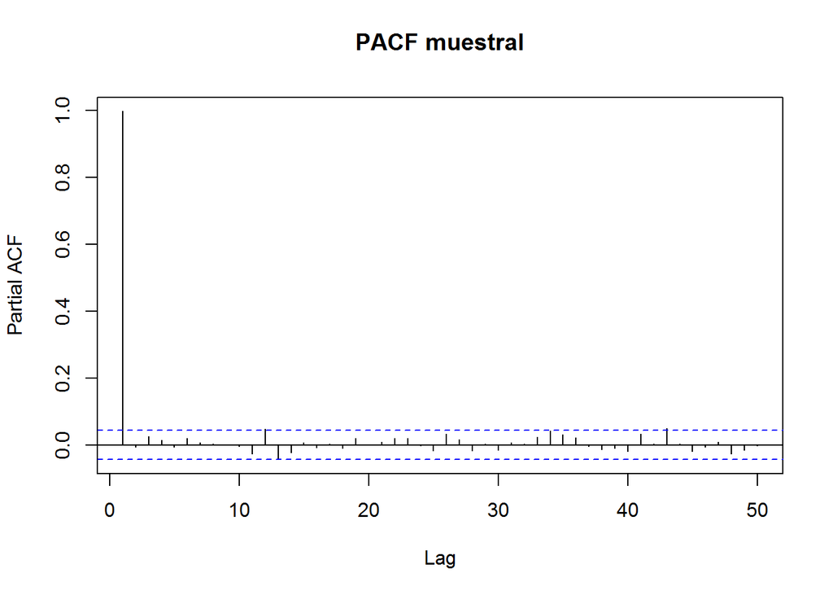

2. Identifique y estime un modelo de memoria larga para la serie $\nu_t$.

Se diferencia una vez la serie usando el operador $(1-B)$ y se grafica nuevamente la serie, su ACF y PACF

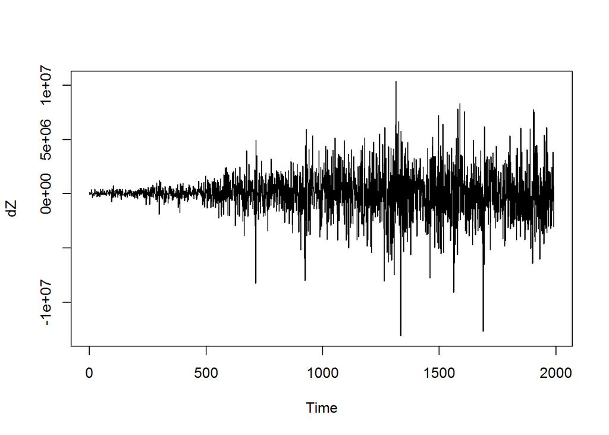

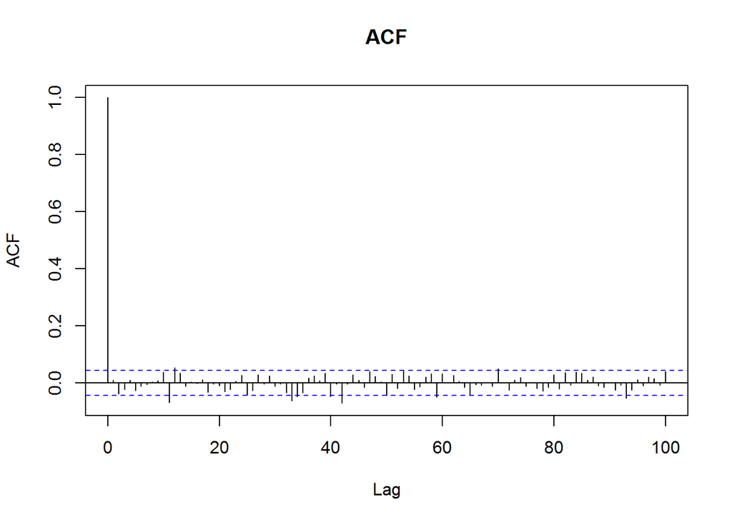

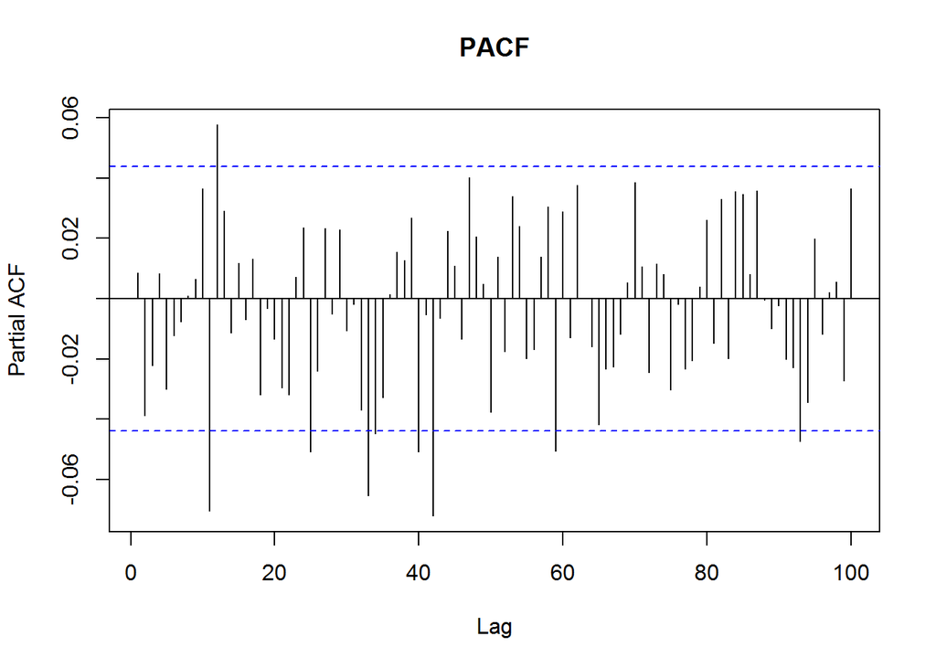

Luego de diferenciar la serie observamos que media es un poco más constante, en la ACF vemos que a partir del rezago 1 deja de ser tan significativa, sin embargo más adelante en algunos puntos hay significancia. El comportamiento de la PACF tampoco es tan claro, sin embargo dejando un poco de lado la rigurosidad podemos decir que decae exponencialmente, Vamos a probar la hipótesis de memoria larga y a estimar el d

```
## $d
## [1] -0.2291013
##
## $sd.as
## [1] 0.1111113
##
## $sd.reg
## [1] 0.08892475
```

```
## [1] -2.061907
```

```
## [1] 1.644854
```

Obtenemos un d estimado de $-0.22$, y concluimos que hay memoria larga, pasamos a diferenciar fraccionalmente la serie, graficar nuevamente su ACF y su PACF para decidir el orden del modelo que ajustaremos

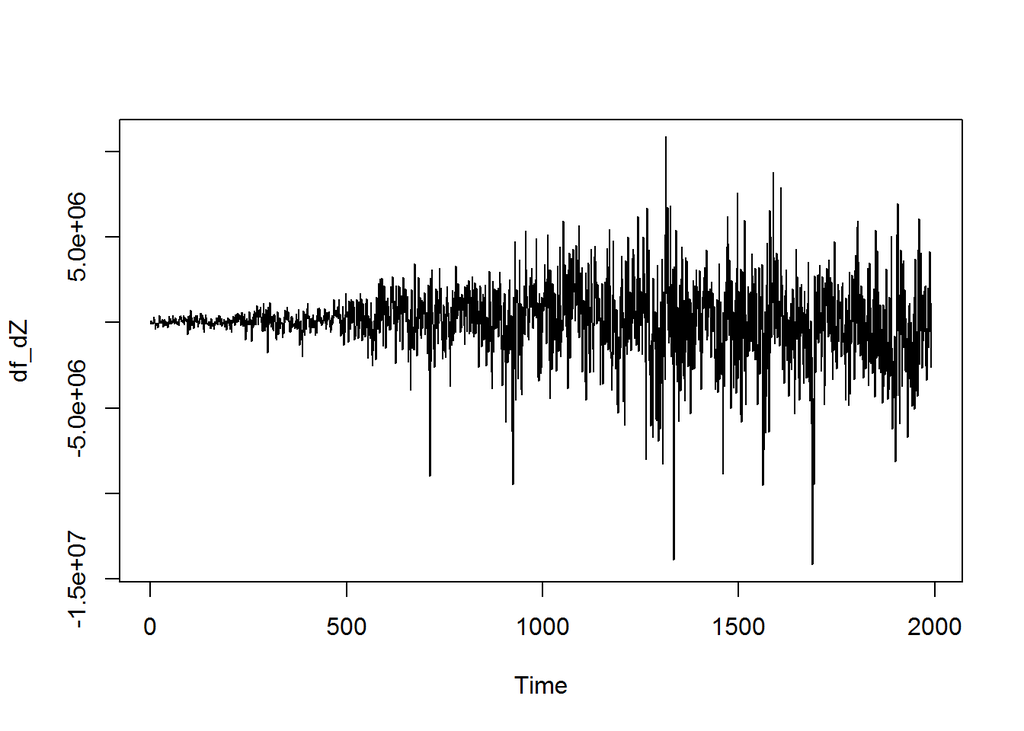

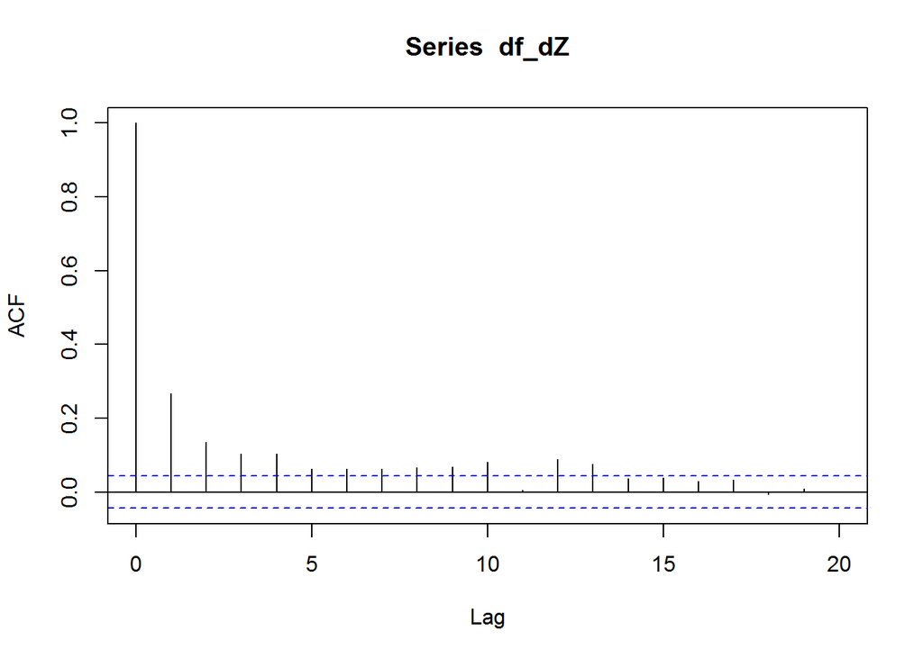

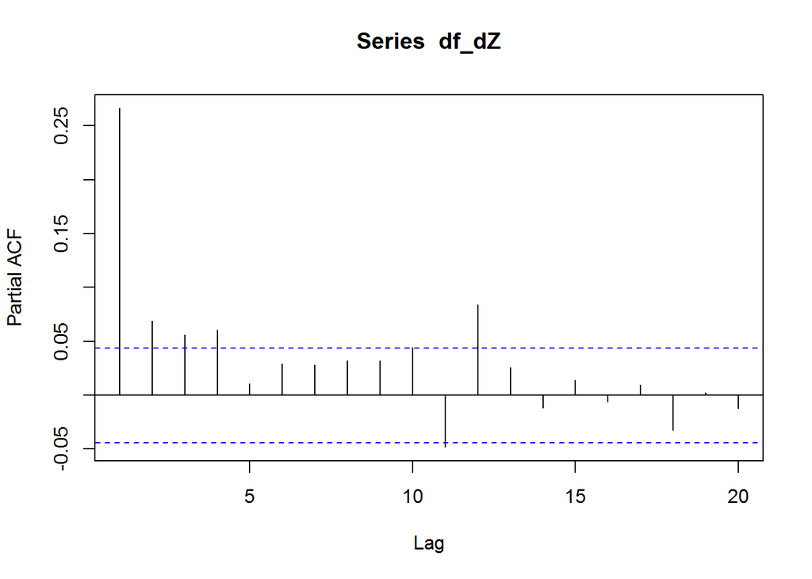

```
##
## Call:
##   fracdiff(x = df_dZ, nma = 1, dtol = NULL, drange = c(0, 0.5),      M = 100)
##
## Coefficients:
##    Estimate Std. Error z value Pr(>|z|)
## d   0.16310    0.02668   6.114 9.74e-10 ***
## ma -0.07376    0.03406  -2.166   0.0303 *
## ---
## Signif. codes:  0 '***' 0.001 '**' 0.01 '*' 0.05 '.' 0.1 ' ' 1
## sigma[eps] = 1992286
## [d.tol = 0.0001221, M = 100, h = 0.0003341]
## Log likelihood: -3.17e+04 ==> AIC = 63414.33 [3 deg.freedom]
```

3. Utilice el modelo final para hacer pronóstico con horizonte $l = 6$. Haga un gráfico de la serie original y de los pronósticos obtenidos.

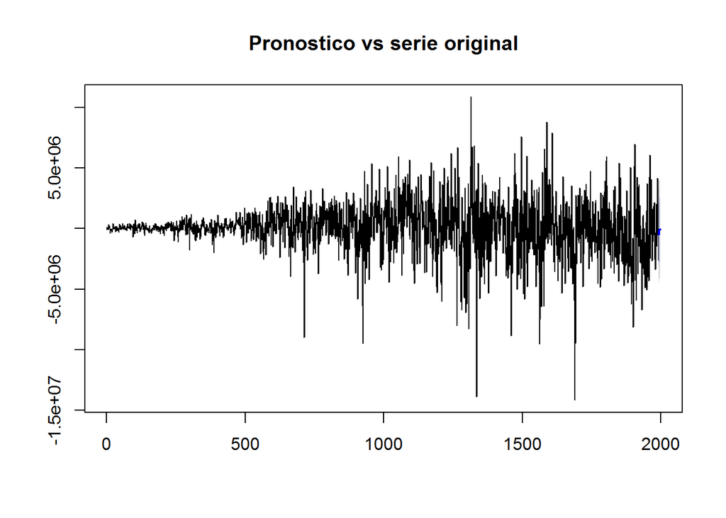

## Punto 7

Los precios spot semanales del petróleo crudo en dólares por barril están en oil; vea el Problema 2.10 y el Apéndice R para más detalles. Investigue si la tasa de crecimiento del precio semanal del petróleo muestra un comportamiento GARCH. Si es así, ajuste un modelo apropiado a la tasa de crecimiento.

Los precios del petróleo son semanales desde el 2000 hasta mediados del 2010, la serie tiene 545 datos.

```
## Time Series:
## Start = c(2000, 1)
## End = c(2000, 6)
## Frequency = 52
## [1] 26.20 26.07 26.34 24.95 26.27 29.37
```

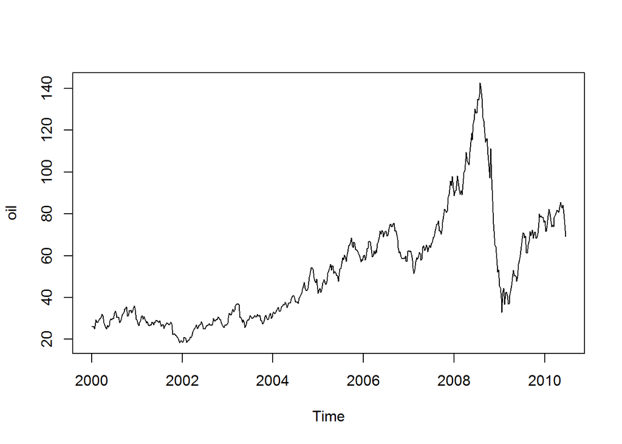

Se calculan los retornos de la serie para asi ver si la tasa de cambio en los precios del petróleo si presenta un comportamiento GARCH

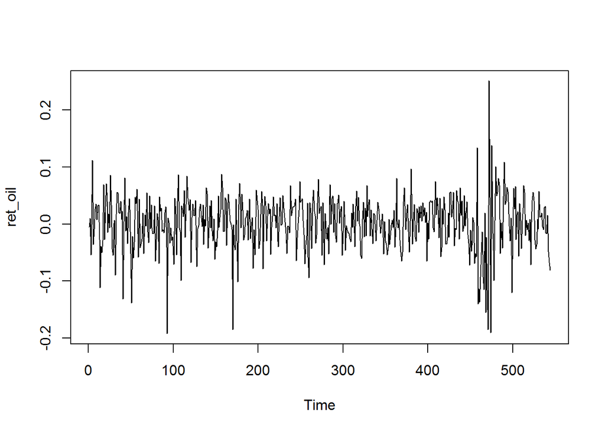

Se observa que para algunos tiempos los retornos presentan volatilidad, aunque en la mayoría presentan estabilidad en su comportamiento. Vamos a analizar si un modelo GARCH si es el adecuado para este caso. Primero ajustaremos un modelo ARIMA(p,d,q) para la media condicional, veamos si la ACF y la PACF dan alguna pista para el orden del modelo.

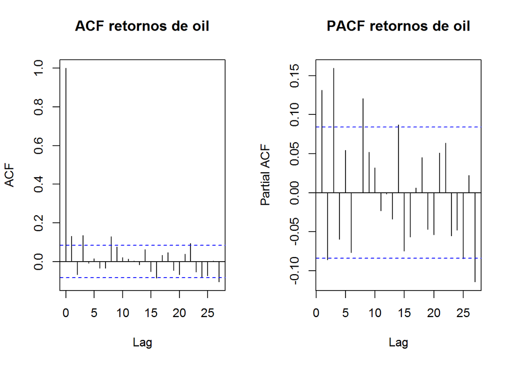

La ACF y la PACF no son claras respecto al orden del modelo, pero podemos iniciar ajustando un modelo sabiendo que podríamos encontrar un mejor modelo con otra combinación de parámetros. Podemos decir que la PACF decae exponencialmente y que la ACF se anula desde el rezago 3, entonces podríamos ajustar un primer modelo MA(3). Pero también podemos mediante una función seleccionar el mejor modelo ARIMA, se procede a ensayar todos los ordenes desde (0,0,0) hasta (3,2,3), el criterio para seleccionar el mejor modelo será el AIC.

Los 5 Mejores Modelos

| Modelos | AIC | BIC | P-D-Q |
| --- | --- | --- | --- |
| Modelo 1 | -1805.339 | -1783.844 | 0-0-3 |
| Modelo 2 | -1804.418 | -1770.026 | 3-0-3 |
| Modelo 3 | -1803.509 | -1777.715 | 3-0-1 |
| Modelo 4 | -1803.398 | -1777.605 | 1-0-3 |
| Modelo 5 | -1801.787 | -1784.591 | 1-0-1 |

Según el criterio del AIC entonces el mejor modelo es ARIMA(0,0,3), procedemos entonces a ajustar el modelo a la serie de los retornos, el modelo ajustado y la gráfica de la serie de los retornos son:

```
## Series: ret_oil
## ARIMA(0,0,3) with non-zero mean
##
## Coefficients:
##          ma1      ma2     ma3    mean
##       0.1688  -0.0900  0.1447  0.0017
## s.e.  0.0424   0.0425  0.0430  0.0024
##
## sigma^2 estimated as 0.002096:  log likelihood=907.67
## AIC=-1805.34   AICc=-1805.23   BIC=-1783.84
##
## Training set error measures:
##                       ME       RMSE        MAE  MPE MAPE      MASE
## Training set 1.90546e-05 0.04561249 0.03415649 -Inf  Inf 0.7543873
##                     ACF1
## Training set 0.002039957
```

[figure not shown]

Observamos un buen ajuste con el modelo ARIMA(0,0,3), lo que sigue es obtener los residuales del modelo

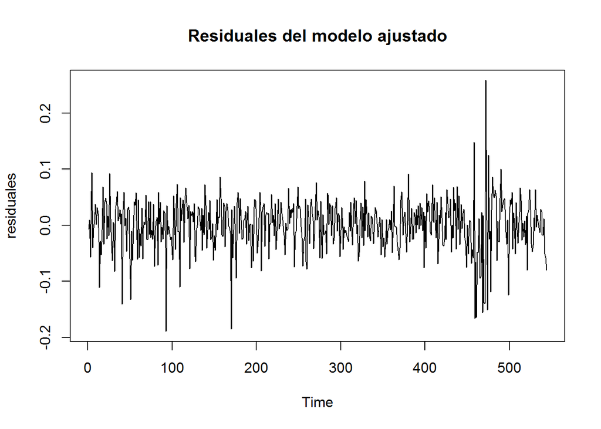

En algunos puntos se observa un comportamiento volátil en los residuales, lo que lleva a sospechar que un modelo GARCH si proporcionará un buen ajuste. Las siguientes son la ACFy PACF de los residuales

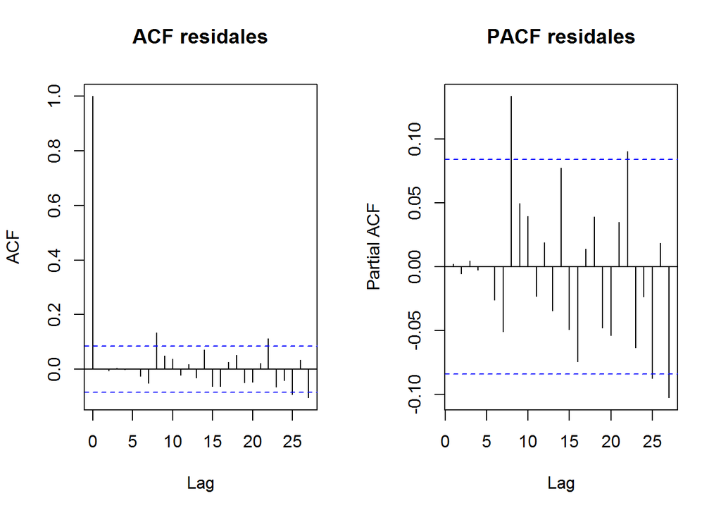

Observamos un comportamiento similar con la ACF y PACF de los retornos, es decir, dejan de ser significativas en los primeros rezagos, pero en rezagos más adelante vuelven a ser significativas. Pero para saber si sí es necesario un modelo GARCH para modelar la varianza debemos ver si los cuadrados de los residuales presentan correlación, si es así entonces debemos usar un modelo GARCH. calculamos entonces los residuales al cuadrado y graficamos su ACF y PACF

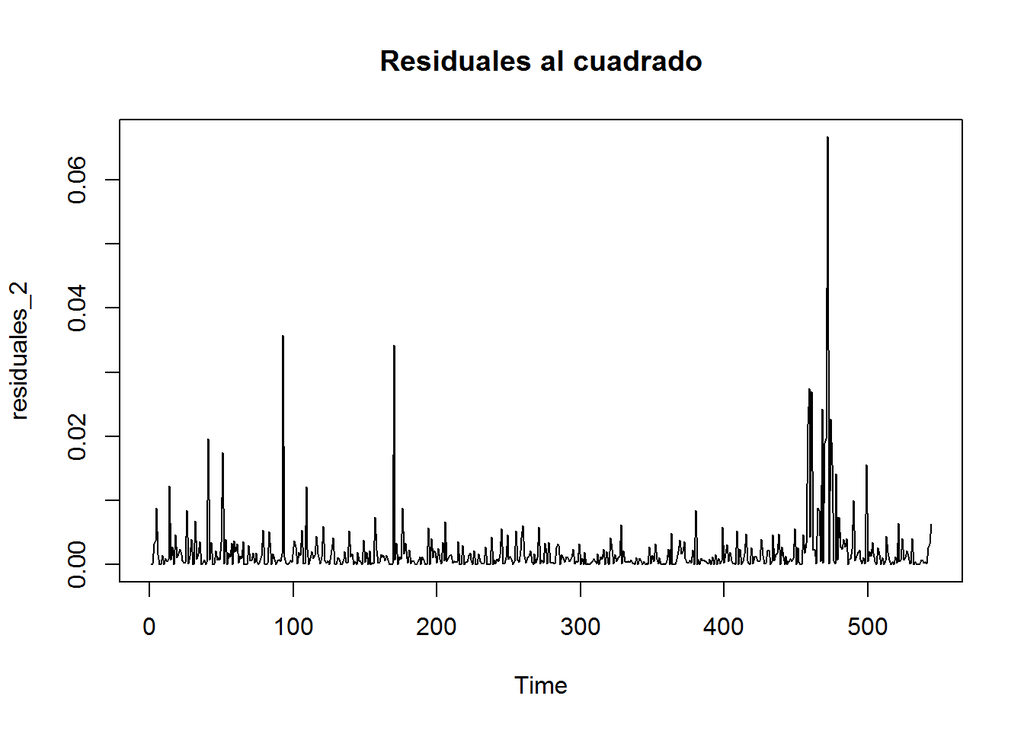

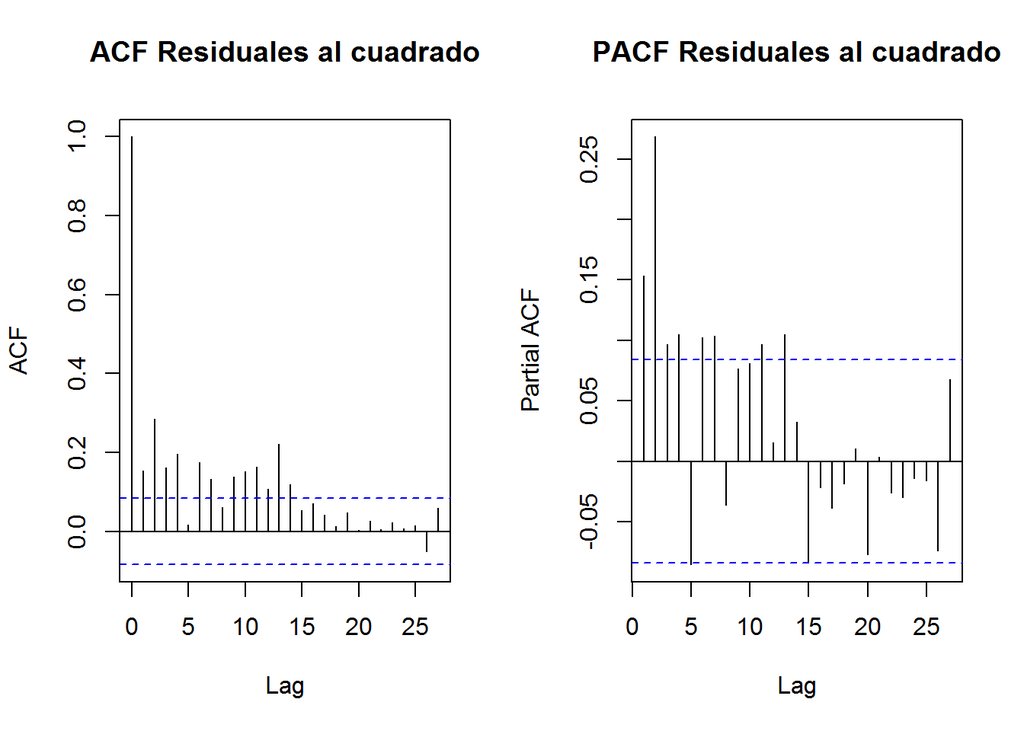

Según la ACF y la PACF de los residuales al cuadrado si sería útil modelar la varianza con un modelo GARCH ya que se observan rezagos significativos, es decir, se observa que existe correlación entre los residuales al cuadrado. Procedemos entonces a ajustar varios modelos GARCH, que según la función de autocorrelación que tiene un decaimiento exponencial y la función de autocorrelación parcial que se corta en los primeros rezagos, se podría ajustar un GARCH(1,0) y un GARCH(2,0) y asi compararlos mediante el AIC y poder elegir el mejor entre ellos. Inicialmente se harán los ajustes bajo la distribución normal.

[output not shown]

[output cut: 51 more lines]

[output not shown]

[output not shown]

[output cut: 70 more lines]

[output not shown]

```
##
## Title:
##  GARCH Modelling
##
## Call:
##  garchFit(formula = ~arma(0, 3) + garch(1, 0), data = ret_oil)
##
## Mean and Variance Equation:
##  data ~ arma(0, 3) + garch(1, 0)
## <environment: 0x000000001d9f37b8>
##  [data = ret_oil]
##
## Conditional Distribution:
##  norm
##
## Coefficient(s):
##         mu         ma1         ma2         ma3       omega      alpha1
##  0.0021941   0.2267495  -0.0498106   0.0651762   0.0016898   0.1799547
##
## Std. Errors:
##  based on Hessian
##
## Error Analysis:
##          Estimate  Std. Error  t value Pr(>|t|)
## mu      0.0021941   0.0023279    0.943  0.34591
## ma1     0.2267495   0.0701358    3.233  0.00122 **
## ma2    -0.0498106   0.0423520   -1.176  0.23955
## ma3     0.0651762   0.0544896    1.196  0.23165
## omega   0.0016898   0.0001327   12.730  < 2e-16 ***
## alpha1  0.1799547   0.0613013    2.936  0.00333 **
## ---
## Signif. codes:  0 '***' 0.001 '**' 0.01 '*' 0.05 '.' 0.1 ' ' 1
##
## Log Likelihood:
##  920.9291    normalized:  1.692884
##
## Description:
##  Wed Dec 05 03:31:16 2018 by user: LEYDI
##
##
## Standardised Residuals Tests:
##                                 Statistic p-Value
##  Jarque-Bera Test   R    Chi^2  131.4582  0
##  Shapiro-Wilk Test  R    W      0.9671687 1.121445e-09
##  Ljung-Box Test     R    Q(10)  12.44794  0.256195
##  Ljung-Box Test     R    Q(15)  17.29062  0.3017898
##  Ljung-Box Test     R    Q(20)  24.4834   0.2219138
##  Ljung-Box Test     R^2  Q(10)  94.51173  6.661338e-16
##  Ljung-Box Test     R^2  Q(15)  108.6101  3.330669e-16
##  Ljung-Box Test     R^2  Q(20)  114.8127  2.553513e-15
##  LM Arch Test       R    TR^2   61.83672  1.042014e-08
##
## Information Criterion Statistics:
##       AIC       BIC       SIC      HQIC
## -3.363710 -3.316295 -3.363950 -3.345172
```

```
##
## Title:
##  GARCH Modelling
##
## Call:
##  garchFit(formula = ~arma(0, 3) + garch(2, 0), data = ret_oil)
##
## Mean and Variance Equation:
##  data ~ arma(0, 3) + garch(2, 0)
## <environment: 0x000000001cec0d00>
##  [data = ret_oil]
##
## Conditional Distribution:
##  norm
##
## Coefficient(s):
##         mu         ma1         ma2         ma3       omega      alpha1
##  0.0034406   0.2093368  -0.0763669   0.0580122   0.0014828   0.1360444
##     alpha2
##  0.1169475
##
## Std. Errors:
##  based on Hessian
##
## Error Analysis:
##          Estimate  Std. Error  t value Pr(>|t|)
## mu      0.0034406   0.0021855    1.574  0.11541
## ma1     0.2093368   0.0471753    4.437  9.1e-06 ***
## ma2    -0.0763669   0.0504016   -1.515  0.12973
## ma3     0.0580122   0.0470542    1.233  0.21762
## omega   0.0014828   0.0001228   12.071  < 2e-16 ***
## alpha1  0.1360444   0.0523904    2.597  0.00941 **
## alpha2  0.1169475   0.0439236    2.663  0.00776 **
## ---
## Signif. codes:  0 '***' 0.001 '**' 0.01 '*' 0.05 '.' 0.1 ' ' 1
##
## Log Likelihood:
##  931.668    normalized:  1.712625
##
## Description:
##  Wed Dec 05 03:31:16 2018 by user: LEYDI
##
##
## Standardised Residuals Tests:
##                                 Statistic p-Value
##  Jarque-Bera Test   R    Chi^2  105.3351  0
##  Shapiro-Wilk Test  R    W      0.9737782 2.71294e-08
##  Ljung-Box Test     R    Q(10)  10.35879  0.4095989
##  Ljung-Box Test     R    Q(15)  15.85383  0.3918321
##  Ljung-Box Test     R    Q(20)  20.7995   0.4090173
##  Ljung-Box Test     R^2  Q(10)  24.49787  0.006383052
##  Ljung-Box Test     R^2  Q(15)  29.91061  0.01224793
##  Ljung-Box Test     R^2  Q(20)  31.63484  0.04734806
##  LM Arch Test       R    TR^2   23.85658  0.02127398
##
## Information Criterion Statistics:
##       AIC       BIC       SIC      HQIC
## -3.399515 -3.344197 -3.399840 -3.377887
```

[output not shown]

[output cut: 58 more lines]

[output not shown]

[output not shown]

[output cut: 62 more lines]

[output not shown]

```
##
## Title:
##  GARCH Modelling
##
## Call:
##  garchFit(formula = ~arma(0, 3) + garch(1, 0), data = ret_oil,
##     cond.dist = "std")
##
## Mean and Variance Equation:
##  data ~ arma(0, 3) + garch(1, 0)
## <environment: 0x000000001a299428>
##  [data = ret_oil]
##
## Conditional Distribution:
##  std
##
## Coefficient(s):
##         mu         ma1         ma2         ma3       omega      alpha1
##  0.0049992   0.2092741  -0.0493916   0.1159111   0.0018150   0.0977939
##      shape
##  5.9274485
##
## Std. Errors:
##  based on Hessian
##
## Error Analysis:
##          Estimate  Std. Error  t value Pr(>|t|)
## mu      0.0049992   0.0023000    2.174  0.02974 *
## ma1     0.2092741   0.0450615    4.644 3.41e-06 ***
## ma2    -0.0493916   0.0445388   -1.109  0.26745
## ma3     0.1159111   0.0447137    2.592  0.00953 **
## omega   0.0018150   0.0001962    9.251  < 2e-16 ***
## alpha1  0.0977939   0.0592789    1.650  0.09900 .
## shape   5.9274485   1.3794934    4.297 1.73e-05 ***
## ---
## Signif. codes:  0 '***' 0.001 '**' 0.01 '*' 0.05 '.' 0.1 ' ' 1
##
## Log Likelihood:
##  937.114    normalized:  1.722636
##
## Description:
##  Wed Dec 05 03:31:17 2018 by user: LEYDI
##
##
## Standardised Residuals Tests:
##                                 Statistic p-Value
##  Jarque-Bera Test   R    Chi^2  144.0933  0
##  Shapiro-Wilk Test  R    W      0.9645645 3.561128e-10
##  Ljung-Box Test     R    Q(10)  13.25161  0.2099421
##  Ljung-Box Test     R    Q(15)  18.47951  0.2382957
##  Ljung-Box Test     R    Q(20)  26.26887  0.1571145
##  Ljung-Box Test     R^2  Q(10)  113.5775  0
##  Ljung-Box Test     R^2  Q(15)  137.1396  0
##  Ljung-Box Test     R^2  Q(20)  143.2475  0
##  LM Arch Test       R    TR^2   69.62736  3.760505e-10
##
## Information Criterion Statistics:
##       AIC       BIC       SIC      HQIC
## -3.419537 -3.364219 -3.419862 -3.397909
```

```
##
## Title:
##  GARCH Modelling
##
## Call:
##  garchFit(formula = ~arma(0, 3) + garch(2, 0), data = ret_oil,
##     cond.dist = "std")
##
## Mean and Variance Equation:
##  data ~ arma(0, 3) + garch(2, 0)
## <environment: 0x000000001c103f60>
##  [data = ret_oil]
##
## Conditional Distribution:
##  std
##
## Coefficient(s):
##         mu         ma1         ma2         ma3       omega      alpha1
##  0.0054185   0.2050589  -0.0794593   0.0946588   0.0015325   0.0818389
##     alpha2       shape
##  0.1364075   6.9454166
##
## Std. Errors:
##  based on Hessian
##
## Error Analysis:
##          Estimate  Std. Error  t value Pr(>|t|)
## mu      0.0054185   0.0021590    2.510 0.012084 *
## ma1     0.2050589   0.0436100    4.702 2.57e-06 ***
## ma2    -0.0794593   0.0475922   -1.670 0.095001 .
## ma3     0.0946588   0.0452813    2.090 0.036577 *
## omega   0.0015325   0.0001716    8.930  < 2e-16 ***
## alpha1  0.0818389   0.0549132    1.490 0.136137
## alpha2  0.1364075   0.0568084    2.401 0.016342 *
## shape   6.9454166   1.8570690    3.740 0.000184 ***
## ---
## Signif. codes:  0 '***' 0.001 '**' 0.01 '*' 0.05 '.' 0.1 ' ' 1
##
## Log Likelihood:
##  943.7828    normalized:  1.734895
##
## Description:
##  Wed Dec 05 03:31:17 2018 by user: LEYDI
##
##
## Standardised Residuals Tests:
##                                 Statistic p-Value
##  Jarque-Bera Test   R    Chi^2  111.2586  0
##  Shapiro-Wilk Test  R    W      0.9724355 1.370249e-08
##  Ljung-Box Test     R    Q(10)  10.17433  0.4253341
##  Ljung-Box Test     R    Q(15)  16.29716  0.3625817
##  Ljung-Box Test     R    Q(20)  21.41272  0.3732085
##  Ljung-Box Test     R^2  Q(10)  26.49191  0.003131997
##  Ljung-Box Test     R^2  Q(15)  33.26529  0.004312832
##  Ljung-Box Test     R^2  Q(20)  35.65529  0.0168794
##  LM Arch Test       R    TR^2   24.68087  0.01640966
##
## Information Criterion Statistics:
##       AIC       BIC       SIC      HQIC
## -3.440378 -3.377158 -3.440802 -3.415661
```

## Punto 8

El paquete de estadística R contiene los precios de cierre diarios de los cuatro principales índices bursátiles europeos; escriba help(EuStockMarkets) para más detalles. Ajuste un modelo GARCH a las devoluciones de una de estas series y discuta sus hallazgos. (Nota: el conjunto de datos contiene valores reales y no los retornos. Por lo tanto, los datos deben transformarse antes del modelo).

Los datos contienen los índices de: Alemania DAX (Ibis), Suiza SMI, Francia CAC y UK FTSE. Los datos se muestrean en horario comercial, es decir, se omiten los fines de semana y los días festivos.Son 1860 observaciones en 4 variables y son medidas entre 1991-1998.

Se va a trabajar con el SMI(abreviatura de Swiss Market Index, al español “Índice del mercado suizo”), el cual es es un índice bursátil de mercados de acciones que reagrupa a los 20 valores principales (blue chips) del mercado suizo que cotizan en la Bolsa de Zúrich. Primero se cargan los datos, se grafica la serie original, se obtienen los retornos y se grafican estos también

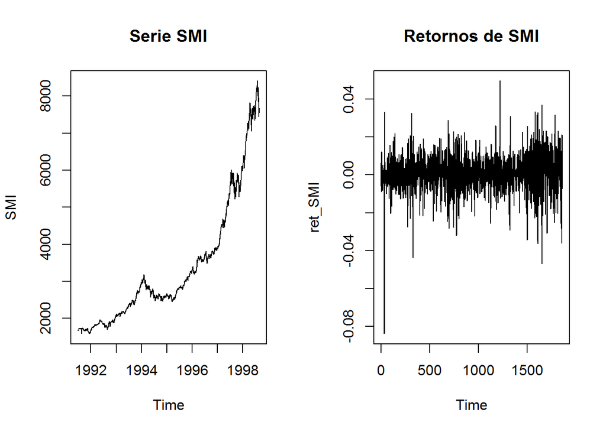

Vamos a probar si realmente es necesario utilizar un modelo GARCH, a pesar de que en la gráfica de los retornos ya observamos volatilidad. Primero debemos hallar el mejor modelo ARIMA(p,d,q) para la media condicional, analizaremos la ACF y la PACF de los retornos del SMI

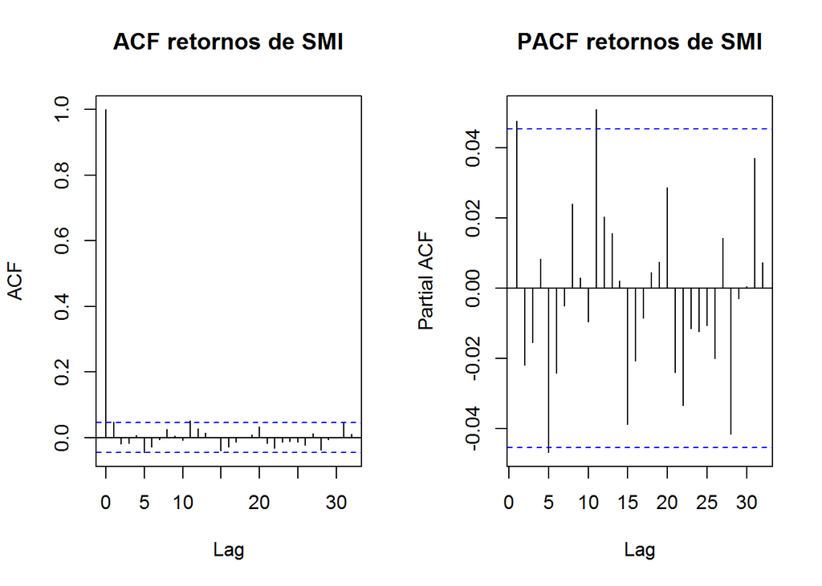

En ninguna de las dos gráficas observamos decaimiento exponencial, por lo que sera difícil determinar el orden del modelo ARIMA(p,d,q), sin embargo hallaremos nuevamente los 5 mejores modelos realizando las combinaciones de parámetros desde (0,0,0) hasta (3,2,3) y usaremos el criterio de selección AIC.

[output not shown]

[output cut: 59 more lines]

[output not shown]

[output not shown]

[output cut: 77 more lines]

[output not shown]

```
##
## Title:
##  GARCH Modelling
##
## Call:
##  garchFit(formula = ~arma(1, 2) + garch(1, 0), data = ret_SMI)
##
## Mean and Variance Equation:
##  data ~ arma(1, 2) + garch(1, 0)
## <environment: 0x000000001cd0a3b0>
##  [data = ret_SMI]
##
## Conditional Distribution:
##  norm
##
## Coefficient(s):
##          mu          ar1          ma1          ma2        omega
##  1.3724e-03  -4.5167e-01   5.6996e-01   9.6266e-02   6.7739e-05
##      alpha1
##  2.1305e-01
##
## Std. Errors:
##  based on Hessian
##
## Error Analysis:
##          Estimate  Std. Error  t value Pr(>|t|)
## mu      1.372e-03   4.071e-04    3.371 0.000748 ***
## ar1    -4.517e-01   2.505e-01   -1.803 0.071361 .
## ma1     5.700e-01   2.487e-01    2.292 0.021908 *
## ma2     9.627e-02   3.432e-02    2.805 0.005028 **
## omega   6.774e-05   3.038e-06   22.299  < 2e-16 ***
## alpha1  2.131e-01   3.944e-02    5.402 6.57e-08 ***
## ---
## Signif. codes:  0 '***' 0.001 '**' 0.01 '*' 0.05 '.' 0.1 ' ' 1
##
## Log Likelihood:
##  6114.16    normalized:  3.288951
##
## Description:
##  Wed Dec 05 03:31:28 2018 by user: LEYDI
##
##
## Standardised Residuals Tests:
##                                 Statistic p-Value
##  Jarque-Bera Test   R    Chi^2  2169.697  0
##  Shapiro-Wilk Test  R    W      0.9643386 0
##  Ljung-Box Test     R    Q(10)  11.13353  0.3472101
##  Ljung-Box Test     R    Q(15)  18.49257  0.2376555
##  Ljung-Box Test     R    Q(20)  20.93138  0.4011814
##  Ljung-Box Test     R^2  Q(10)  20.46242  0.02517021
##  Ljung-Box Test     R^2  Q(15)  22.75567  0.08946692
##  Ljung-Box Test     R^2  Q(20)  23.88485  0.2474584
##  LM Arch Test       R    TR^2   18.3116   0.1065517
##
## Information Criterion Statistics:
##       AIC       BIC       SIC      HQIC
## -6.571447 -6.553606 -6.571467 -6.564872
```

```
##
## Title:
##  GARCH Modelling
##
## Call:
##  garchFit(formula = ~arma(1, 2) + garch(3, 0), data = ret_SMI)
##
## Mean and Variance Equation:
##  data ~ arma(1, 2) + garch(3, 0)
## <environment: 0x0000000019c09460>
##  [data = ret_SMI]
##
## Conditional Distribution:
##  norm
##
## Coefficient(s):
##          mu          ar1          ma1          ma2        omega
##  1.5485e-03  -4.4171e-01   5.2123e-01   5.2433e-02   5.7015e-05
##      alpha1       alpha2       alpha3
##  1.4230e-01   9.7195e-02   9.4824e-02
##
## Std. Errors:
##  based on Hessian
##
## Error Analysis:
##          Estimate  Std. Error  t value Pr(>|t|)
## mu      1.549e-03   5.754e-04    2.691 0.007117 **
## ar1    -4.417e-01   4.538e-01   -0.973 0.330417
## ma1     5.212e-01   4.551e-01    1.145 0.252045
## ma2     5.243e-02   5.311e-02    0.987 0.323531
## omega   5.702e-05   3.191e-06   17.867  < 2e-16 ***
## alpha1  1.423e-01   3.591e-02    3.963  7.4e-05 ***
## alpha2  9.720e-02   2.780e-02    3.497 0.000471 ***
## alpha3  9.482e-02   2.717e-02    3.489 0.000484 ***
## ---
## Signif. codes:  0 '***' 0.001 '**' 0.01 '*' 0.05 '.' 0.1 ' ' 1
##
## Log Likelihood:
##  6136.31    normalized:  3.300866
##
## Description:
##  Wed Dec 05 03:31:30 2018 by user: LEYDI
##
##
## Standardised Residuals Tests:
##                                 Statistic p-Value
##  Jarque-Bera Test   R    Chi^2  3877.065  0
##  Shapiro-Wilk Test  R    W      0.9590346 0
##  Ljung-Box Test     R    Q(10)  8.07444   0.6215658
##  Ljung-Box Test     R    Q(15)  14.31963  0.501439
##  Ljung-Box Test     R    Q(20)  16.50297  0.6849718
##  Ljung-Box Test     R^2  Q(10)  2.330673  0.9931203
##  Ljung-Box Test     R^2  Q(15)  2.742673  0.9997706
##  Ljung-Box Test     R^2  Q(20)  3.058697  0.9999952
##  LM Arch Test       R    TR^2   2.332255  0.9987002
##
## Information Criterion Statistics:
##       AIC       BIC       SIC      HQIC
## -6.593125 -6.569337 -6.593162 -6.584358
```

Ahora bajo la distribución t

[output not shown]

[output cut: 56 more lines]

[output not shown]

[output not shown]

[output cut: 86 more lines]

[output not shown]

```
##
## Title:
##  GARCH Modelling
##
## Call:
##  garchFit(formula = ~arma(1, 2) + garch(1, 0), data = ret_SMI,
##     cond.dist = "std")
##
## Mean and Variance Equation:
##  data ~ arma(1, 2) + garch(1, 0)
## <environment: 0x000000001c2208b0>
##  [data = ret_SMI]
##
## Conditional Distribution:
##  std
##
## Coefficient(s):
##          mu          ar1          ma1          ma2        omega
##  1.2441e-03  -1.3505e-01   1.8764e-01   3.0925e-03   6.9301e-05
##      alpha1        shape
##  1.9965e-01   4.7435e+00
##
## Std. Errors:
##  based on Hessian
##
## Error Analysis:
##          Estimate  Std. Error  t value Pr(>|t|)
## mu      1.244e-03   6.696e-04    1.858   0.0632 .
## ar1    -1.351e-01   5.880e-01   -0.230   0.8183
## ma1     1.876e-01   5.899e-01    0.318   0.7504
## ma2     3.093e-03   4.773e-02    0.065   0.9483
## omega   6.930e-05   4.714e-06   14.700  < 2e-16 ***
## alpha1  1.997e-01   4.443e-02    4.494 6.99e-06 ***
## shape   4.743e+00   5.395e-01    8.792  < 2e-16 ***
## ---
## Signif. codes:  0 '***' 0.001 '**' 0.01 '*' 0.05 '.' 0.1 ' ' 1
##
## Log Likelihood:
##  6205.071    normalized:  3.337854
##
## Description:
##  Wed Dec 05 03:31:32 2018 by user: LEYDI
##
##
## Standardised Residuals Tests:
##                                 Statistic p-Value
##  Jarque-Bera Test   R    Chi^2  2421.042  0
##  Shapiro-Wilk Test  R    W      0.9606248 0
##  Ljung-Box Test     R    Q(10)  10.25176  0.4186905
##  Ljung-Box Test     R    Q(15)  18.04973  0.26006
##  Ljung-Box Test     R    Q(20)  20.6722   0.4166475
##  Ljung-Box Test     R^2  Q(10)  23.22002  0.009962945
##  Ljung-Box Test     R^2  Q(15)  26.16257  0.03634829
##  Ljung-Box Test     R^2  Q(20)  27.38312  0.1248253
##  LM Arch Test       R    TR^2   20.69186  0.05507895
##
## Information Criterion Statistics:
##       AIC       BIC       SIC      HQIC
## -6.668178 -6.647363 -6.668206 -6.660507
```

```
##
## Title:
##  GARCH Modelling
##
## Call:
##  garchFit(formula = ~arma(1, 2) + garch(3, 0), data = ret_SMI,
##     cond.dist = "std")
##
## Mean and Variance Equation:
##  data ~ arma(1, 2) + garch(3, 0)
## <environment: 0x0000000018064840>
##  [data = ret_SMI]
##
## Conditional Distribution:
##  std
##
## Coefficient(s):
##          mu          ar1          ma1          ma2        omega
##  1.0442e-03   1.0872e-01  -7.3454e-02  -2.4092e-02   5.2469e-05
##      alpha1       alpha2       alpha3        shape
##  1.2179e-01   1.4409e-01   1.2386e-01   5.3007e+00
##
## Std. Errors:
##  based on Hessian
##
## Error Analysis:
##          Estimate  Std. Error  t value Pr(>|t|)
## mu      1.044e-03   8.003e-04    1.305 0.191976
## ar1     1.087e-01   6.755e-01    0.161 0.872133
## ma1    -7.345e-02   6.752e-01   -0.109 0.913373
## ma2    -2.409e-02   3.932e-02   -0.613 0.540029
## omega   5.247e-05   4.144e-06   12.661  < 2e-16 ***
## alpha1  1.218e-01   3.699e-02    3.293 0.000992 ***
## alpha2  1.441e-01   4.009e-02    3.594 0.000326 ***
## alpha3  1.239e-01   3.714e-02    3.335 0.000853 ***
## shape   5.301e+00   6.473e-01    8.189 2.22e-16 ***
## ---
## Signif. codes:  0 '***' 0.001 '**' 0.01 '*' 0.05 '.' 0.1 ' ' 1
##
## Log Likelihood:
##  6228.696    normalized:  3.350562
##
## Description:
##  Wed Dec 05 03:31:35 2018 by user: LEYDI
##
##
## Standardised Residuals Tests:
##                                 Statistic p-Value
##  Jarque-Bera Test   R    Chi^2  5035.398  0
##  Shapiro-Wilk Test  R    W      0.9547478 0
##  Ljung-Box Test     R    Q(10)  10.27894  0.4163709
##  Ljung-Box Test     R    Q(15)  16.10926  0.3748277
##  Ljung-Box Test     R    Q(20)  18.22456  0.572618
##  Ljung-Box Test     R^2  Q(10)  2.113879  0.9953905
##  Ljung-Box Test     R^2  Q(15)  2.546546  0.9998568
##  Ljung-Box Test     R^2  Q(20)  2.77912   0.9999979
##  LM Arch Test       R    TR^2   2.144988  0.9991492
##
## Information Criterion Statistics:
##       AIC       BIC       SIC      HQIC
## -6.691442 -6.664680 -6.691489 -6.681579
```

Concluimos que el modelo que proporciona el mejor ajuste es el GARCH(3,0) con un AIC del -6.69, ya que es menor de los cuatro modelos ajustamos